# A3: SPL Library Checkouts

### Introduction

For my project, I’m analyzing the data set with items checked out at least 10 times a month from 2017-20203. The authors, forms of checkout, and subjects are my main variables that I will look at. I want to analyze how the amount of physical checkouts have changed throughout the years, to see whether physical checkouts or digital checkouts are more popular as of 2023, compared to previous years. I also want to analyze books about politics, and how their popularity have changed over the years, as protests, and politics have become more prominent especially in social media. I think the influence of social media is quite big especially in today’s age and I think it can be proven through my analysis of popular genres, authors, and technology taken from this data.

### The Dataset

- Who collected/published the data?

  The Seattle Public Library
- What are the parameters of the data (dates, number of checkouts, kinds of books, etc.)?

  The data is checkouts from 2017-2023, and has 12 variables, and 816354 observations. It includes data of titles and authors for physical and electronically checked out books.
- How was the data collected or generated?

  It was collected digitally through a system as books got checked out from the library.
- Why was the data collected?

  To see the checkouts throughout the years, and which books have been checked out by month, and either digitally or physically.
- What, if any, ethical questions do you need to consider when working with this data?

  Ethically speaking, it’s probably important to recognize that people don’t know their data is being taken when checking out a book, especially digitally can lead to ethical issues. I also think ethically, we can’t use this data to say whether someone actually likes a book without knowing if they read it, but instead it is just to see which books are circulating the most within the library.
- What are possible limitations or problems with this data? (at least 200 words)

  I think we need to consider how big the data set is, and while that sounds like the opposite of limitations, it can actually cause problems when it comes to analyzing the data. I noticed multiple occurrences where authors names will be entered differently so if you try to filter for example, for “Colleen Hoover” it won’t calculate some of the data because it was entered in the data set as “Hoover Colleen” , etc. and the same with titles or series of books which can make working with the data a little more difficult. I also think which such raw data like this it can lead to certain miscalculations where the same people may have checked out the same book multiple times, which I feel like can throw off some of the data when it comes to analyzing certain trends. People can also checkout books by accident, and then return them to the library quickly after because they didn’t like it which can also be a potential implication since this data does not show returns. I think for data like this, we need something like a survey to actually see what books people like or find interesting, because just this data won’t definitively tell us likelihood but rather raw data on what is most commonly being checked out, disregarding if it’s actually being read or not.

### First Trends Over Time Chart

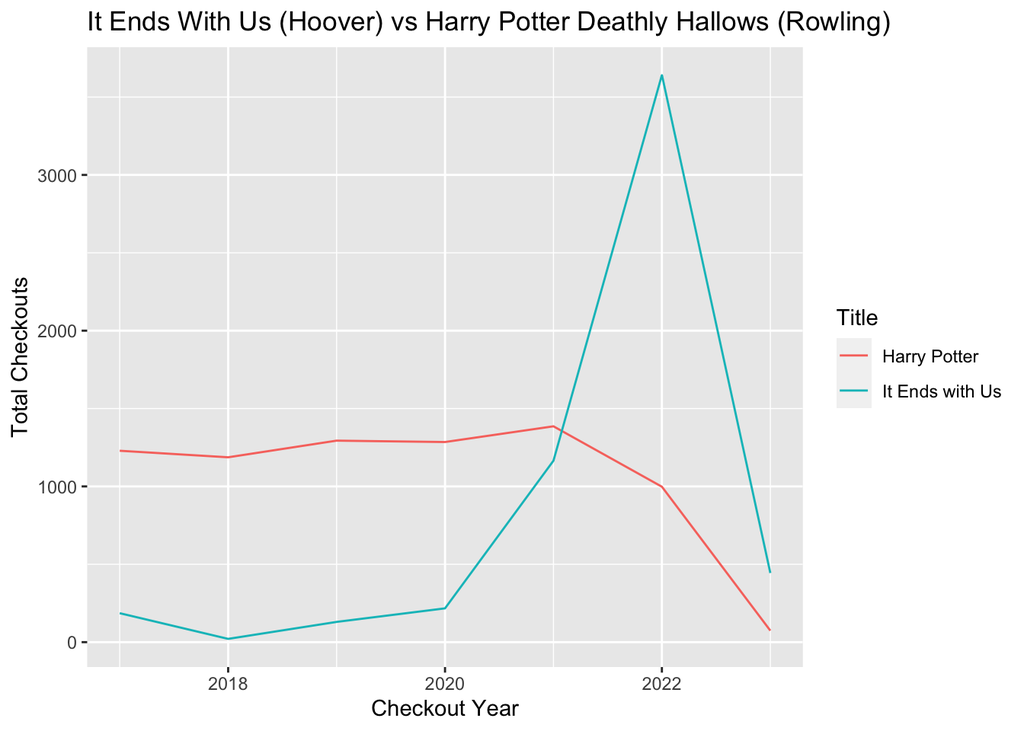

### Second Trends Over Time Chart

For my second chart, I analyzed which year had the highest number of checked out books related to politics. I also wanted to see the type of politics book that was being checked out, because I think that allows for an understanding of the generation who’s checking out the book, and trends with how people access reading materials. I feel like politics have become very prominent in our community as protests are increasing, and people are taking more action towards certain issues so I wanted to see if that reflected in the books people checked out. I found that 2020 actually had the highest number of books checked out relating to politics and they were checked out as Audio books, which I don’t actually find surprising. With the rise of the pandemic, it not only makes sense that more online books were checked out due to quarantine, but also it was a very divided time for a lot of people in terms of political beliefs and laws put in place surrounding COVID.

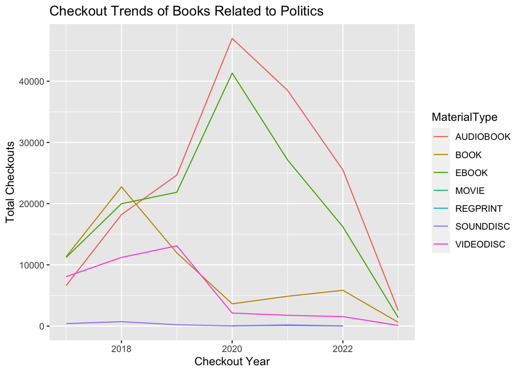

### Your Choice

In my third chart I chose to compare digital checkouts vs physical checkouts. I was initially going to see which type of checkouts are more popular overall, but instead chose to focus on 2023, to see if people are still checking out books physically, or if it has transformed to fully digital checkouts. I grouped by UsageClass, and combined with the maximum checkouts in 2023. I found that checkouts made digitally were nearly double the size of physical checkouts this year. It goes to show the impact of technology and I’m interested to see the ways public libraries begin to develop more innovative forms of checking out books.

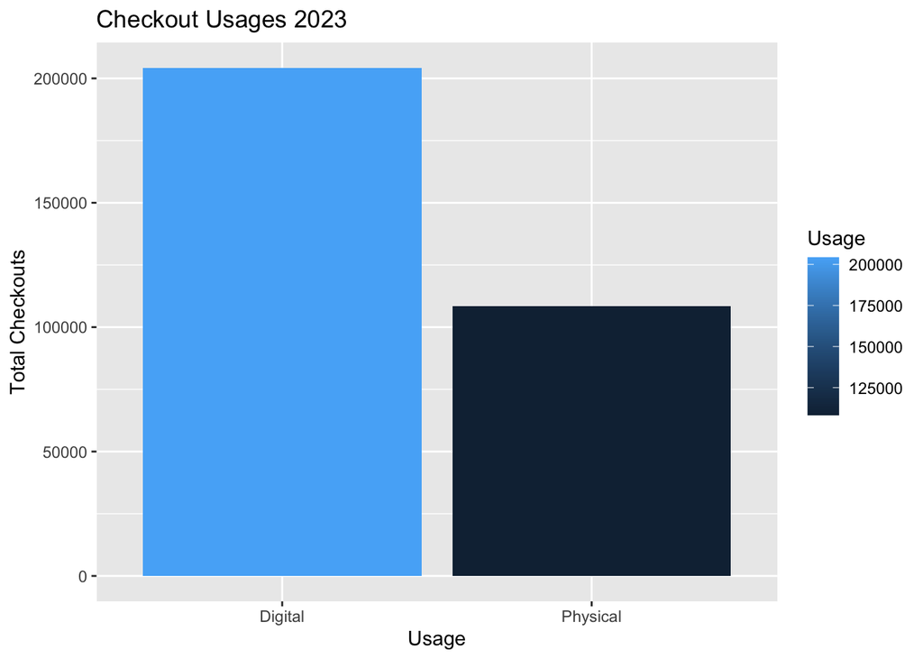